# Excess death in the US by age

Dan Weinberger

2/5/2022

Popsize for the CDC data

Setup CDC data and merge with popsize

Look at COVID deaths (based on ICD10) by group

https://www.cdc.gov/nchs/nvss/bridged_race/data_documentation.htm#vintage2020

Race: Race: RACE_RECODE: 1=Non-Hispanic White 2=Non-Hispanic- Black 3= Hispanic 4=American Indian/Native Alaskan 5= Asian/Pacific Island 999=Missing

Sex: 0 = Total 1 = Male 2 = Female

The key for ORIGIN is as follows: 0 = Total 1 = Not Hispanic 2 = Hispanic

01 … Under 1 year (includes not stated infant ages) 02 … 1 - 4 years 03 … 5 - 14 years 04 … 15 - 24 years 05 … 25 - 34 years 06 … 35 - 44 years 07 … 45 - 54 years 08 … 55 - 64 years 09 … 65 - 74 years 10 … 75 - 84 years 11 … 85 years and over 12 … Age not stated

## Check inputs

Should be 1,012,805 deaths among 85+ year olds in 2020 1,013,340

In the US the death rate in 2019: 3,319,063 deaths among people age 25+; 226,635,013 people age 25+ 1,464.5 deaths/100000

## Fit Model

Fit to VA and CDC data separately. This function saves to an rds file summary tables with the excess incidence and RR by group (excluding raw counts and denominators). It also outputs the full summary tables that can be used in plotting in the list out.ds

## Extract summary stats for table 2

```
#> $overall.results
#> [1] "1.22 (95%CI:1.19, 1.25)"
#> $overall.results
#> [1] "1.2 (95%CI:1.18, 1.22)"
#> $overall.results
#> [1] "203 (95%CI:178, 225)"
#> $overall.results
#> [1] "429 (95%CI:392, 463)"
#> $overall.results
#> [1] "927 (95%CI:905, 952)"
#> $overall.results
#> [1] "2159 (95%CI:2125, 2196)"
#> $overall.results
#> [1] "2159 (95%CI:2125, 2196)"
#> [1] 1129.948
#> [1] 2587.915
```

Number of deaths

|  | source | agec | excess_median |
| --- | --- | --- | --- |
| 1 | cdc | 25-44 years | 26253 |
| 2 | cdc | 45-64 years | 86980 |
| 3 | cdc | 65-74 years | 93310 |
| 4 | cdc | 75-84 years | 114770 |
| 5 | cdc | 85 years and older | 138140 |

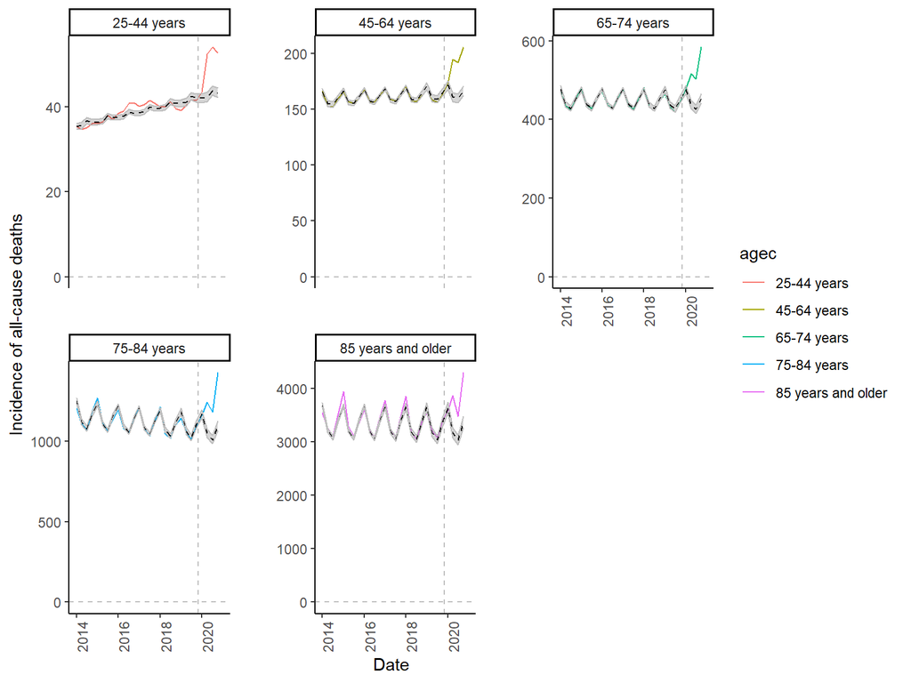

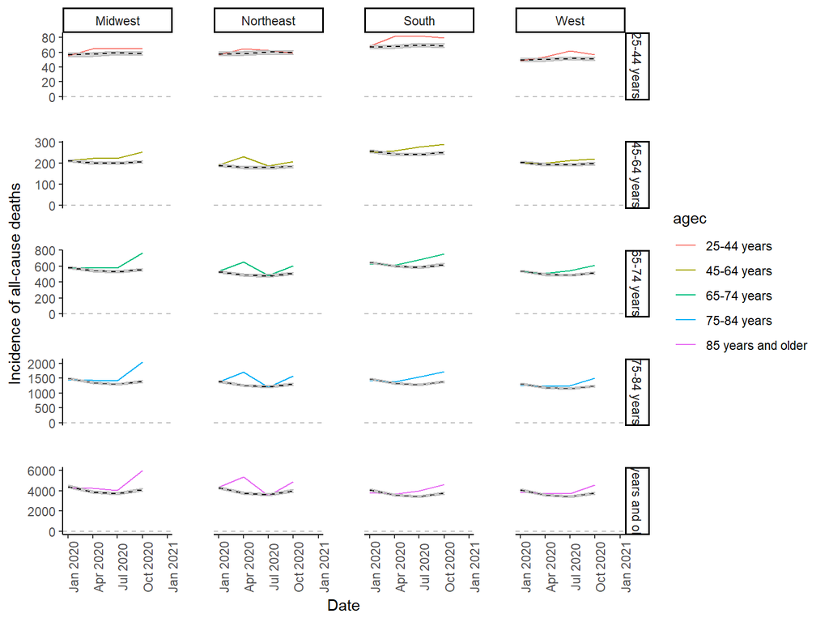

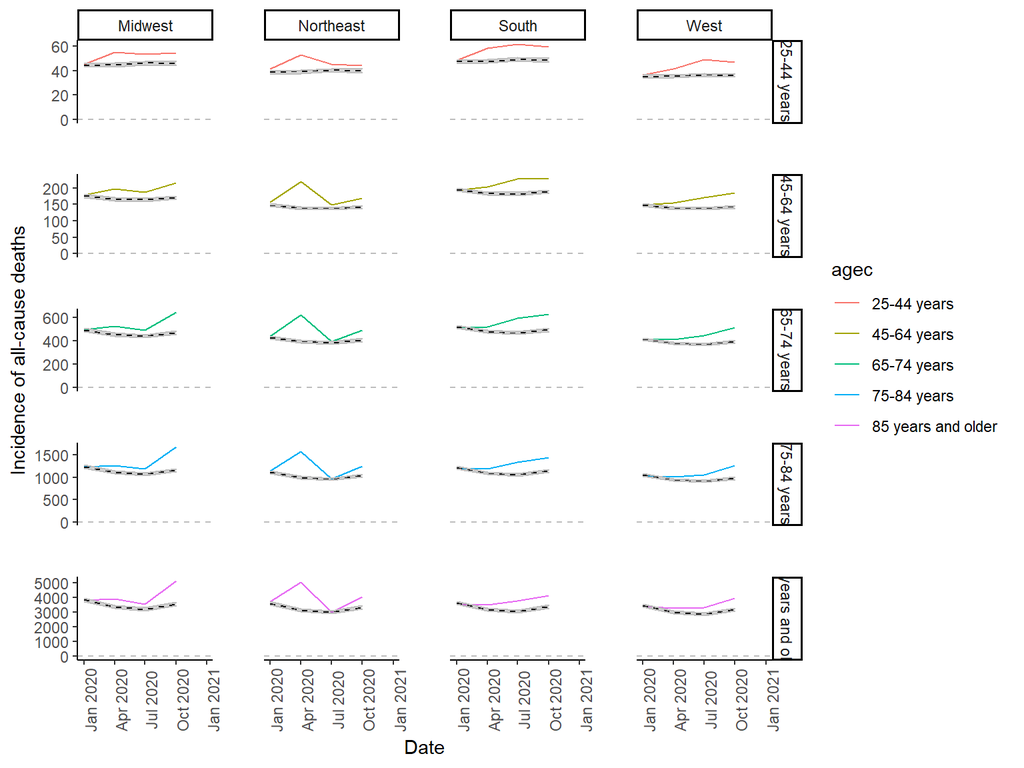

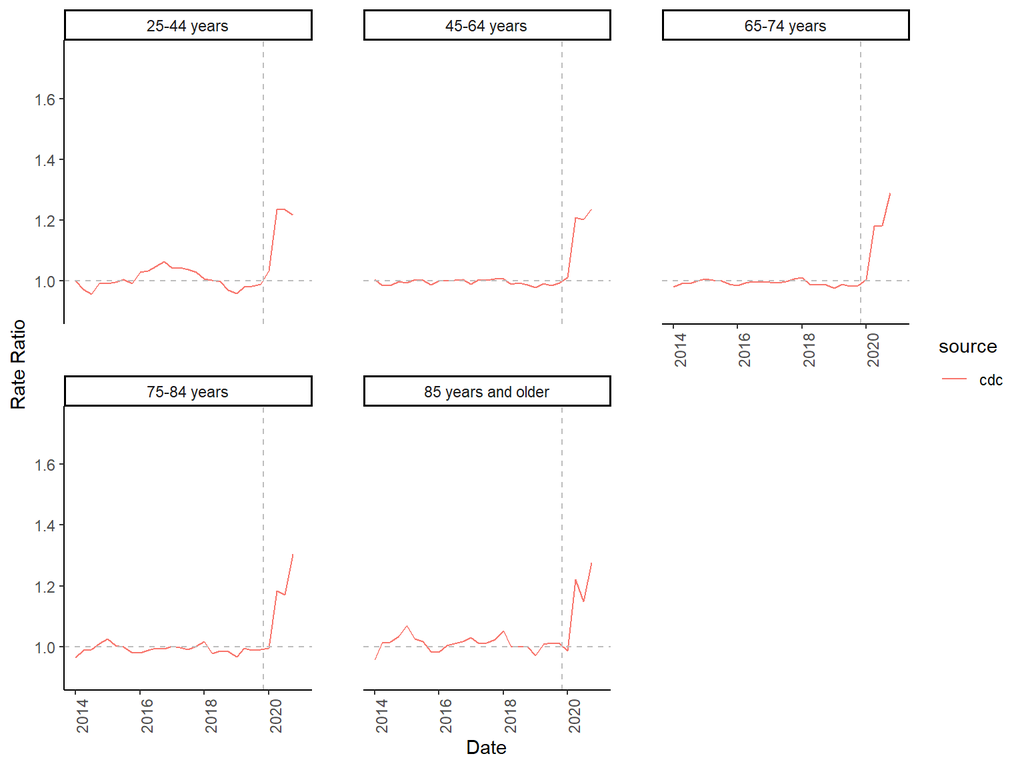

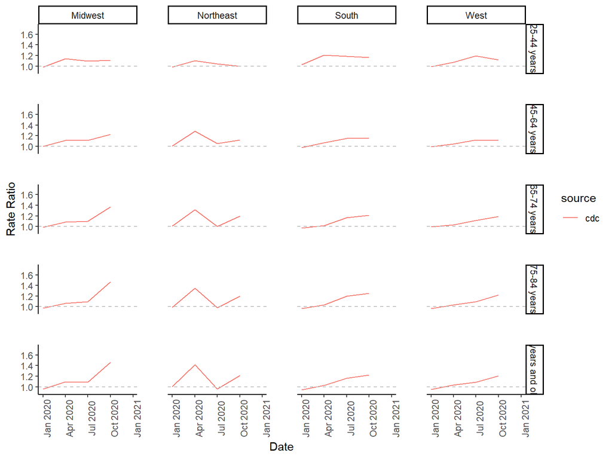

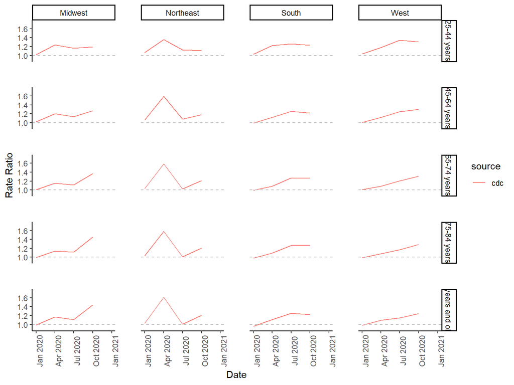

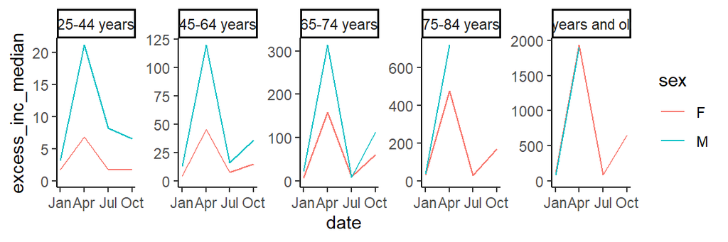

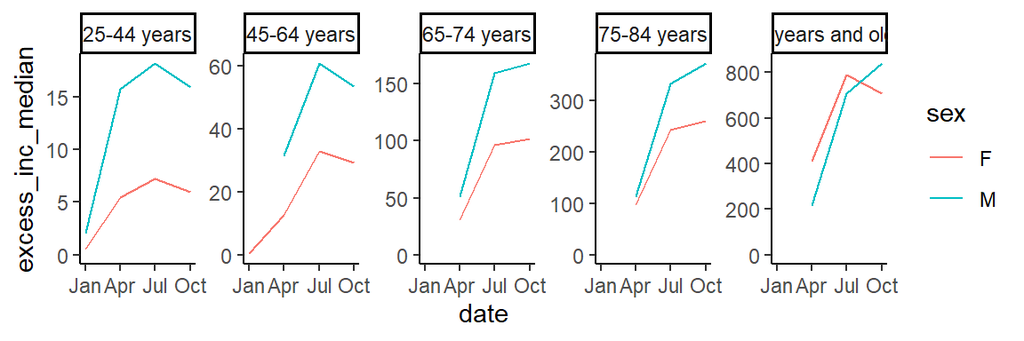

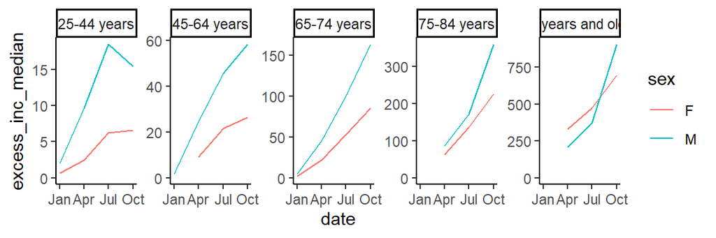

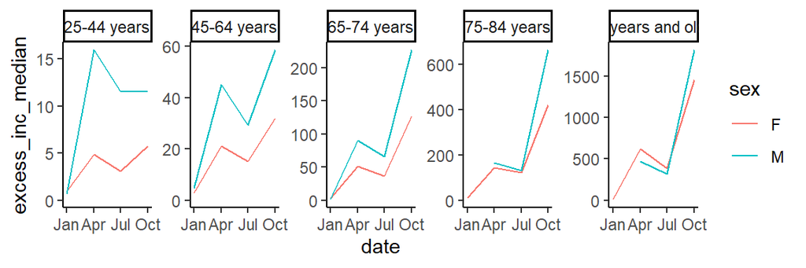

RR by race in the Northeast, by sex

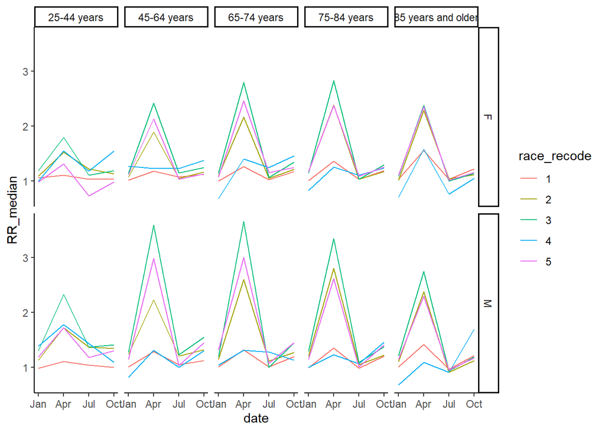

Sex differences by race and age in the northeast

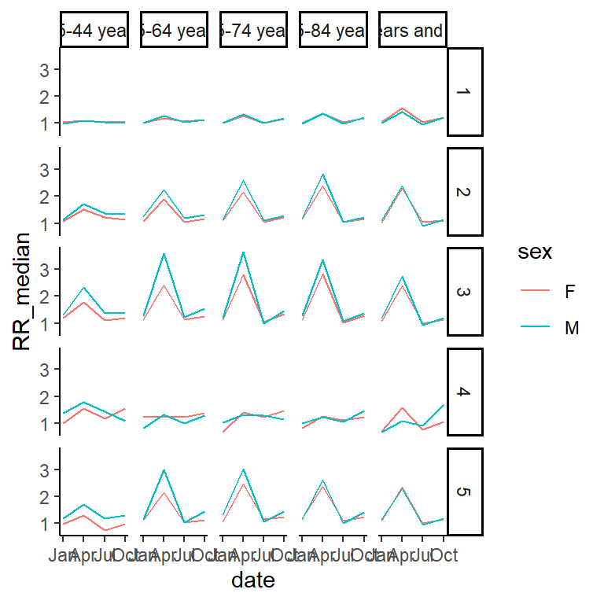

[figure not shown]

And in the South

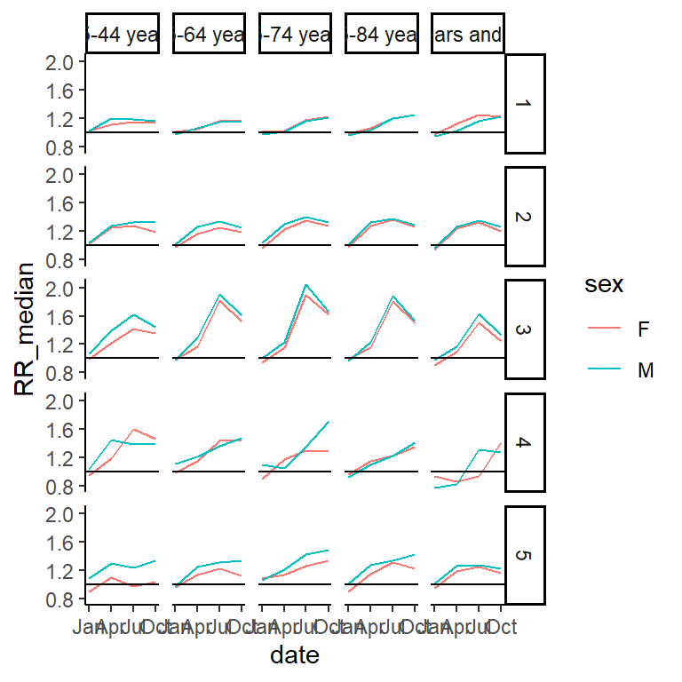

[figure not shown]

## Compare excess and recorded covid

‘non-COVID’ means deaths not recorded as due to covid

RACE_RECODE: 1=Non-Hispanic White 2=Non-Hispanic- Black 3= Hispanic 4=American Indian/Native Alaskan 5= Asian/Pacific Island 999=Missing

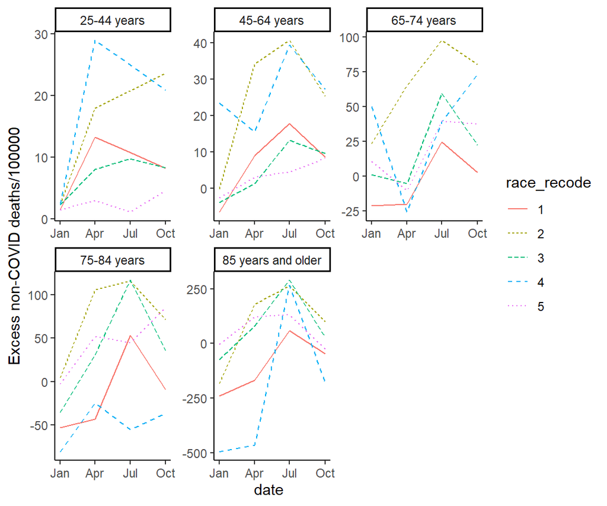

Overall by race, age

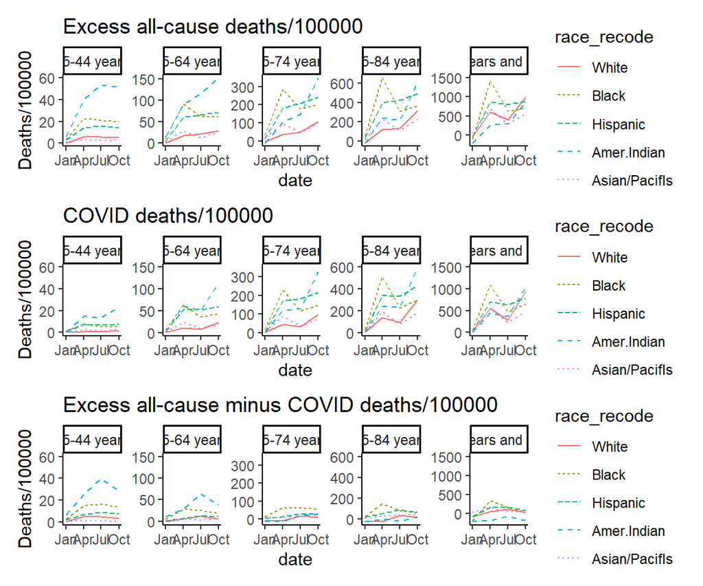

by race, age NE only

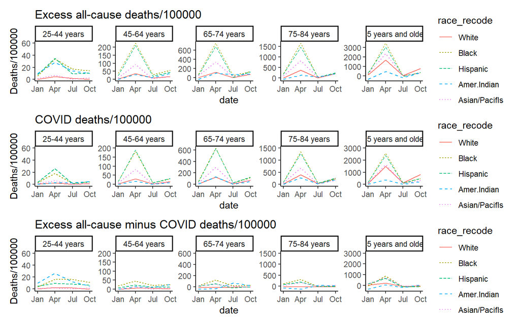

by race, age Midwest only

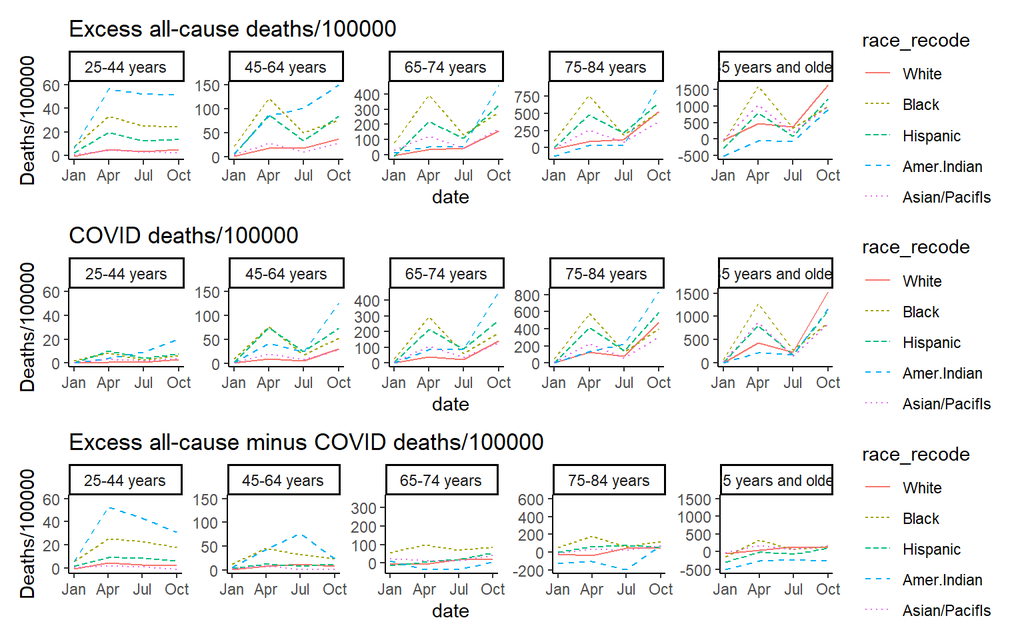

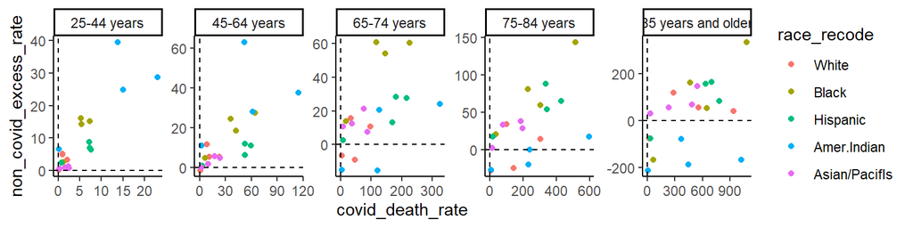